# Lab 1: The R Shakedown

## An aside: the `apply()` function

Now in the spirit of preparing us for the functions we will see in the near-ish future, and since we just used the `tapply()` function, let me illustrate how might use the `apply()` function. This function simply, well, *applies* a function to each row or column (i.e., a margin) of an array or matrix. Margins are represented by `1` for rows or `2` for columns. Let’s try it.

```r
apply(bySpp,
      MARGIN = 2,
      FUN = summary)
```

```
        MIMO      PEMA      TAAM ZAPR
Min.       1  1.000000  1.000000    1
1st Qu.    1  1.000000  1.000000    1
Median     1  2.000000  1.000000    1
Mean       1  2.528736  1.685185    1
3rd Qu.    1  3.500000  2.000000    1
Max.       1  8.000000  6.000000    1
NA's     142 56.000000 89.000000  139
```

So, it gives us the same basic information (with different formatting) as before. But we can use it more broadly, too.

For instance, what do you think this will do?

```r
apply(smammals,
      MARGIN = 2,
      FUN = min, na.rm = TRUE)
```

Really. Take a second and think before moving on…

.  
.  
.

```
         Tag         Date     Transect      Station      Species          Sex
       "100" "2019-06-04"          "B"        "  1"       "MIMO"          "F"
         Age        Repro       Weight          Ear     Hindfoot         Tail
         "A"         "EP"       "11.0"         "11"       "17.0"        " 46"
       Total         Body
       "128"        " 65"
```

Notice that the data frame, `smammals` was coerced into a matrix which can only accommodate a single data type. In this case the lowest common denominator was `character`, so all of the columns became character types.

Try changing the the function or the margin to see if you understand how this works. Bonus points for trying it on one of your own data sets.

Anyway, here in this context this function is a bit less useful than `tapply()`, but it *will* be used a lot in this course. So consider this your gentle introduction to `apply()`.

# Example 2: Weather data from loggers

As is often the case, we happen to have weather data from nearby data loggers in a separate data set from the trapping data. The `climate` data set can be found [here](https://s3.wp.wsu.edu/uploads/sites/1097/2019/09/Climate.csv).

## Load and check the data

Load them in—don’t forget to to format the date and look at the data.

```r
climate <- read.csv("https://s3.wp.wsu.edu/uploads/sites/1097/2019/09/Climate.csv")
head(climate)
```

```
  LoggerID       Date        Time Temperature     RH
1      A19 06/01/2019 12:28:01 AM      21.158 88.618
2      A19 06/01/2019  1:28:01 AM      21.158 88.102
3      A19 06/01/2019  2:28:01 AM      21.158 88.102
4      A19 06/01/2019  3:28:01 AM      20.658 88.618
5      A19 06/01/2019  4:28:01 AM      20.157 90.666
6      A19 06/01/2019  5:28:01 AM      19.657 92.185
```

```r
tail(climate)
```

```
      LoggerID       Date        Time Temperature  RH
34981     MN19 08/31/2019  6:03:01 PM      19.582 100
34982     MN19 08/31/2019  7:03:01 PM      19.081 100
34983     MN19 08/31/2019  8:03:01 PM      18.581 100
34984     MN19 08/31/2019  9:03:01 PM      18.581 100
34985     MN19 08/31/2019 10:03:01 PM      18.581 100
34986     MN19 08/31/2019 11:03:01 PM      18.080 100
```

```r
summary(climate)
```

```
   LoggerID             Date               Time            Temperature
 Length:34986       Length:34986       Length:34986       Min.   : 8.103
 Class :character   Class :character   Class :character   1st Qu.:18.083
 Mode  :character   Mode  :character   Mode  :character   Median :21.127
                                                          Mean   :21.278
                                                          3rd Qu.:24.137
                                                          Max.   :44.085
       RH
 Min.   : 22.55
 1st Qu.: 79.53
 Median : 93.02
 Mean   : 86.81
 3rd Qu.: 99.67
 Max.   :100.00
```

Notice the columns for temperature (degrees C) and relative humidity (%). It looks like we get data every hour, so there should be ~24 readings per day. Finally, there are blessedly no missing data or apparent wonkiness—though note that `Date` and `Time` are still treated as character, so there could be gremlins lurking there.

See, too, that there are multiple data loggers.

```r
unique(climate$LoggerID)
```

```
 [1] "A19"  "B1"   "E7"   "H18"  "J4"   "J18"  "L19"  "M8"   "P1"   "R15"
[11] "F11"  "F4"   "G8"   "H14"  "J2"   "K16"  "M7"   "P8"   "R14"  "X14"
[21] "A20"  "K7"   "O12"  "Q6"   "X16"  "X6"   "Y7"   "B16"  "G13"  "G18"
[31] "H4"   "J17"  "O7"   "P5"   "T12"  "Z20"  "MN19"
```

Now imagine that what we need to do is calculate the average daily temperature across all of the loggers for each day. (And a heads up, we may not have the same number of loggers operating on any given day. Does that matter?) So here’s what we need to do:

1. Correct the `Date` column so it is treated as a date
2. Calculate the average temperature for each loggers for each day
3. Calculate the average daily temperature across the active loggers

Before proceeding, stare off into space for a second and think about how you would approach this. What would your strategy be? Do you see a way forward?

.  
.  
.

## Adjust the variable

This should be the easy-ish part. Look above to see how we changed a vector of dates treated as characters to a vector of dates treated as dates. I won’t show you the code—you need to try it—but here is the result:

```r
# INSERT CODE TO MAKE COLUMN "Date" A DATE
summary(climate$Date)
```

```
        Min.      1st Qu.       Median         Mean      3rd Qu.         Max.
"2019-06-01" "2019-07-03" "2019-07-22" "2019-07-22" "2019-08-14" "2019-08-31"
```

So now `Date` is a real date and we can see that our data set goes from June 1 to August 31. That makes sense, so no (obvious) gremlins here!

**Warning**

Times of day are usually not dealt with independently of date[^2], which as cause me no shortage of frustration in the past. So let me just show you how to convert both the date and the time to a date-time column. In essence, we are going to paste together the two vectors with `paste()` and the provide the format of that date-time agglomeration.

```r
climate$DT <- strptime(paste(climate$Date, climate$Time),
                       format = "%Y-%m-%d %H:%M:%S")
head(climate)
```

```
  LoggerID       Date        Time Temperature     RH                  DT
1      A19 2019-06-01 12:28:01 AM      21.158 88.618 2019-06-01 12:28:01
2      A19 2019-06-01  1:28:01 AM      21.158 88.102 2019-06-01 01:28:01
3      A19 2019-06-01  2:28:01 AM      21.158 88.102 2019-06-01 02:28:01
4      A19 2019-06-01  3:28:01 AM      20.658 88.618 2019-06-01 03:28:01
5      A19 2019-06-01  4:28:01 AM      20.157 90.666 2019-06-01 04:28:01
6      A19 2019-06-01  5:28:01 AM      19.657 92.185 2019-06-01 05:28:01
```

```r
str(climate)
```

```
'data.frame':   34986 obs. of  6 variables:
 $ LoggerID   : chr  "A19" "A19" "A19" "A19" ...
 $ Date       : Date, format: "2019-06-01" "2019-06-01" ...
 $ Time       : chr  "12:28:01 AM" "1:28:01 AM" "2:28:01 AM" "3:28:01 AM" ...
 $ Temperature: num  21.2 21.2 21.2 20.7 20.2 ...
 $ RH         : num  88.6 88.1 88.1 88.6 90.7 ...
 $ DT         : POSIXlt, format: "2019-06-01 12:28:01" "2019-06-01 01:28:01" ...
```

Getting sensible values out of this, as opposed to just formatting the output so it shows you what you like (see the help files), is…difficult. If you often need to do this I would *strongly* recommend keeping separate columns for hours, or maybe something like minutes from midnight that you can more easily do math on. That said, methods do exist and you can use them, but it won’t (initially) be easy. Phew! Go that off my chest. Now we can move on.

## Calculate summaries

Again, we first want to calculate the mean for each logger on each day. We can use `tapply()` again. Here the thing we want our function applied to is the temperature and we want to first organize these temperature data by logger and date (or vice versa… try reversing the arguments in the list and see what happens).

```r
daily_logger <- tapply(X = climate$Temperature,
                       INDEX = list(climate$Date, climate$LoggerID),
                       FUN = mean)

head(daily_logger)
```

```
                A19 A20       B1 B16       E7 F11 F4 G13 G18 G8 H14      H18 H4
2019-06-01 24.90804  NA 25.19387  NA 24.76275  NA NA  NA  NA NA  NA 25.34242 NA
2019-06-02 17.61113  NA 17.58629  NA 17.52896  NA NA  NA  NA NA  NA 17.52563 NA
2019-06-03 15.60754  NA 15.52096  NA 15.40088  NA NA  NA  NA NA  NA 15.83475 NA
2019-06-04 13.60392  NA 13.68521  NA 13.41892  NA NA  NA  NA NA  NA 13.64379 NA
2019-06-05 12.37175  NA 12.18233  NA 12.14546  NA NA  NA  NA NA  NA 12.09842 NA
2019-06-06 14.02112  NA 14.03954  NA 13.91938  NA NA  NA  NA NA  NA 13.99817 NA
           J17 J18 J2 J4 K16 K7      L19 M7       M8 MN19 O12 O7       P1 P5 P8
2019-06-01  NA  NA NA NA  NA NA 26.10271 NA 24.54858   NA  NA NA 25.06612 NA NA
2019-06-02  NA  NA NA NA  NA NA 18.47358 NA 17.48050   NA  NA NA 17.87625 NA NA
2019-06-03  NA  NA NA NA  NA NA 16.30171 NA 15.64375   NA  NA NA 15.60367 NA NA
2019-06-04  NA  NA NA NA  NA NA 14.40142 NA 13.51504   NA  NA NA 13.56042 NA NA
2019-06-05  NA  NA NA NA  NA NA 13.02175 NA 12.34563   NA  NA NA 12.26717 NA NA
2019-06-06  NA  NA NA NA  NA NA 15.02717 NA 13.95312   NA  NA NA 14.16475 NA NA
           Q6 R14      R15 T12 X14 X16 X6 Y7 Z20
2019-06-01 NA  NA 24.00354  NA  NA  NA NA NA  NA
2019-06-02 NA  NA 17.28967  NA  NA  NA NA NA  NA
2019-06-03 NA  NA 15.28592  NA  NA  NA NA NA  NA
2019-06-04 NA  NA 13.26133  NA  NA  NA NA NA  NA
2019-06-05 NA  NA 11.73663  NA  NA  NA NA NA  NA
2019-06-06 NA  NA 13.42783  NA  NA  NA NA NA  NA
```

Please notice the structure of the data before proceeding. Each row is a date and each column a logger. There are a lot of `NA`s simply because that particular logger was not deployed on that particular day.

Now, if I were to suggest you use `apply()` to apply the `mean()` function to this new matrix, `daily_logger`, which margin would you want it to be applied to? That is, should we take the average of each row or each column? (And if we had reverse the arguments to `INDEX`, above, would we need to change this?)

OK, here goes…

```r
daily <- apply(X=daily_logger,
               MARGIN = 1,
               FUN = mean, na.rm=TRUE)

head(daily)
```

```
2019-06-01 2019-06-02 2019-06-03 2019-06-04 2019-06-05 2019-06-06
  24.99101   17.67150   15.64990   13.63626   12.27114   14.06889
```

Before moving on, make sure you understand what those functions *do*. What happens if we didn’t that that `na.rm=TRUE` in the command? Why?

Finally, be sure you see whether this is what we actually wanted to produce.

## Plot the data

The only problem with our data as it is formatted is that it’s just a vector of values (mean temperatures) with no dates. I mean, they are there, but in the form of rownames. So we can plot these values:

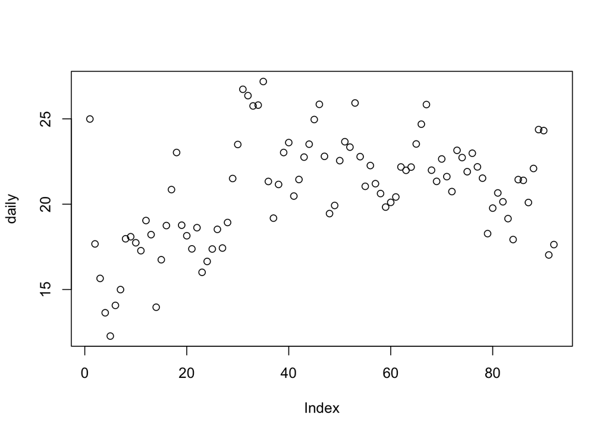

```r
plot(daily)
```

but they are plotted against the index of their position in the vector, not by date. We can clean this up a bit:

```r
daily <- data.frame(daily)
head(daily)
```

```
              daily
2019-06-01 24.99101
2019-06-02 17.67150
2019-06-03 15.64990
2019-06-04 13.63626
2019-06-05 12.27114
2019-06-06 14.06889
```

```r
# use the rownames to make a date column
daily$Date = as.Date(rownames(daily))
str(daily)
```

```
'data.frame':   92 obs. of  2 variables:
 $ daily: num  25 17.7 15.6 13.6 12.3 ...
 $ Date : Date, format: "2019-06-01" "2019-06-02" ...
```

```r
# change the name of the temperature variable
colnames(daily)[1] <- "MeanTemp" # see what I'm doing?
```

And then we can plot it nicer

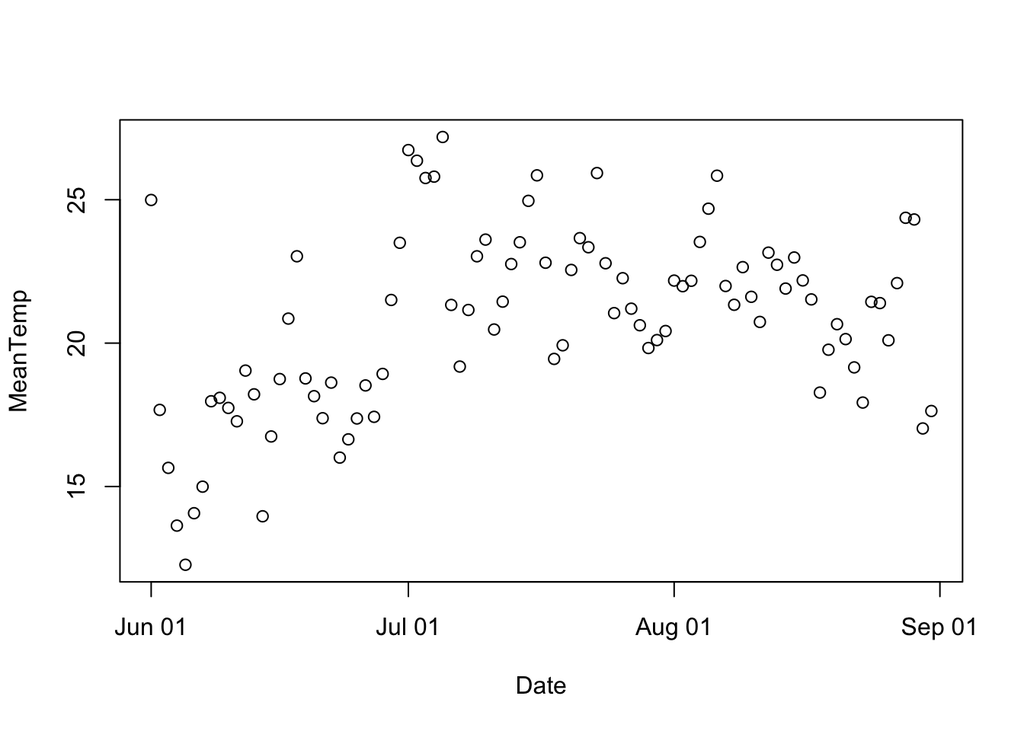

```r
plot(MeanTemp ~ Date, data = daily)
```

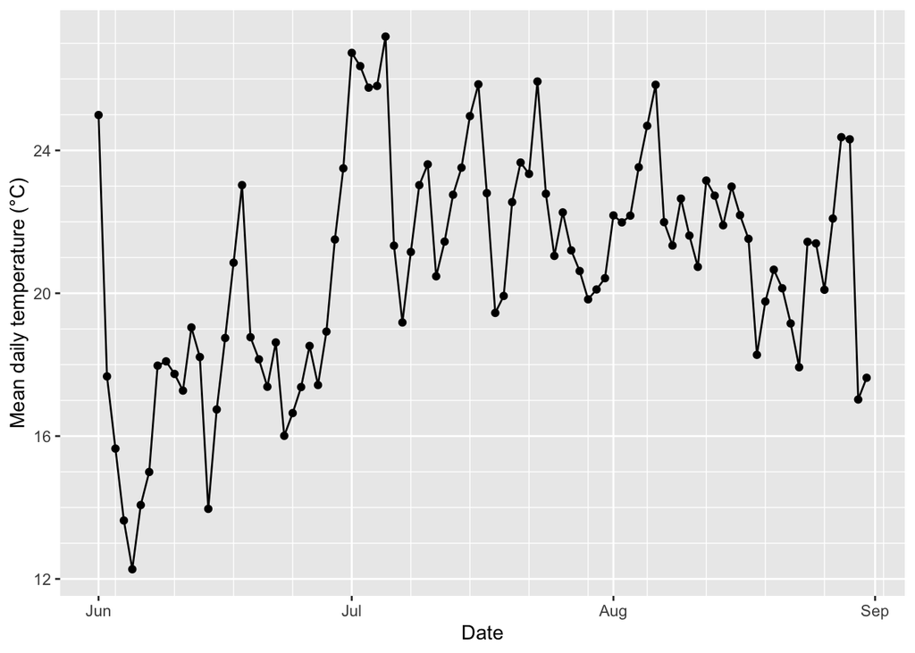

```r
# Or
ggplot(data = daily, aes(x=Date, y = MeanTemp)) +
  geom_line() + geom_point() +
  scale_x_date(minor_breaks = "week") +
  scale_y_continuous("Mean daily temperature (°C)",
                     minor_breaks = 10:30)
```

# Example 3: vapor pressure deficit & functions

The `climate` data set has temperature and humidity, but not vapor pressure deficit (VPD), a measure of the drying potential of the conditions[^3]. That, however, can be calculated as:
$$0.6108 \times \exp \left(17.27 \times \frac{T}{ (T + 237.3)}\right) \times \left(1-\frac{RH}{100}\right).$$

Your final tasks are to use the tools we’ve seen already to calculate and plot the VPD over the site across all of the loggers, and plot the maximum VPD recorded by each logger as a quality control check. I will not show you the code—just the results—but I will give you one last tool to use.

## An aside on functions

We could calculate VPD by hand, each time we needed, or we could make a function to do so and use that function whenever we needed to calculate VPD. That sounds easier, long run. So, let us learn about writing functions.

A function is written as:

```r
name_of_fxn <- function(argument1, argument2, ...){
  #Stuff to do.
  return()
}
```

The arguments in the parentheses of `function()` are what the function uses[^4]. The thing in the parentheses of `return()` is what is given back. A function can only be one thing, but that thing can be a value, vector, list, and so on. So it can include a lot of stuff. Or nothing. So, anyway, a function that calculated the mean of two numbers could be written as:

```r
mean2 <- function(x1, x2){
  m <- (x1+x2)/2
  return(m)
}
mean2(x1=12, x2=35)
```

```
[1] 23.5
```

One important aspect of variable names within functions is that the names are “local.” This means that while the `mean2()` function uses two variables called `x1` and `x2`, those are *internal* to the function. If you had a variable named `x1` elsewhere in your environment, `mean2()` would not know to use that (unless told) and whatever happens in `mean2()` would not change its value.

```r
x1 <- 1000
mean2(x1=5, x2=0)
```

```
[1] 2.5
```

```r
x1 # unchanged
```

```
[1] 1000
```

```r
mean2(x1=5, x2=x1) # = (5+1000)/2
```

```
[1] 502.5
```

```r
x1 # still unchanged
```

```
[1] 1000
```

This behavior can be a bit confusing, but it is important so that someone using a function does not need to know about how it works inside to avoid conflicts or other unexpected behavior.

So anyway, our VPD function might look like this:

```r
vpd <- function(temperature, RH){
  # temperature in °C, RH is a percent

  # saturation vapor pressure
  es <- 0.6108 * exp(17.27 * temperature / (temperature + 237.3))

  # Actual Vapor Pressure (ea) =
  ea <- (RH / 100) * es

    # Vapor Pressure Deficit in kPa
  return (es- ea)
}

vpd(temperature = 25, RH=80) # should be 0.63356
```

```
[1] 0.6335555
```

It is not important that you understand the math, but notice that the function is

- easy to read (multiple lines, common indentations)
- easy to parse (breaks the problem into bite-sized bits)
- well-commented
- it defines variables and provides units

All of that makes it easier to use and maintain. But now, we want to use it.

# Your assignment

1. Plot mean daily VPD against date (with whatever plotting function you like), like we just did with temperature.

```r
climate$VPD <- vpd(temperature=climate$Temperature, RH=climate$RH)


daily_logger <- tapply(X = climate$VPD,
                       INDEX = list(climate$Date,
                                    climate$LoggerID),
                       FUN = mean)

daily <- apply(X = daily_logger,
               MARGIN = 1,
               FUN = mean, na.rm=TRUE)

daily <- data.frame(daily)

daily$Date <- as.Date(rownames(daily))

colnames(daily)[1] <- "MeanVPD"
```

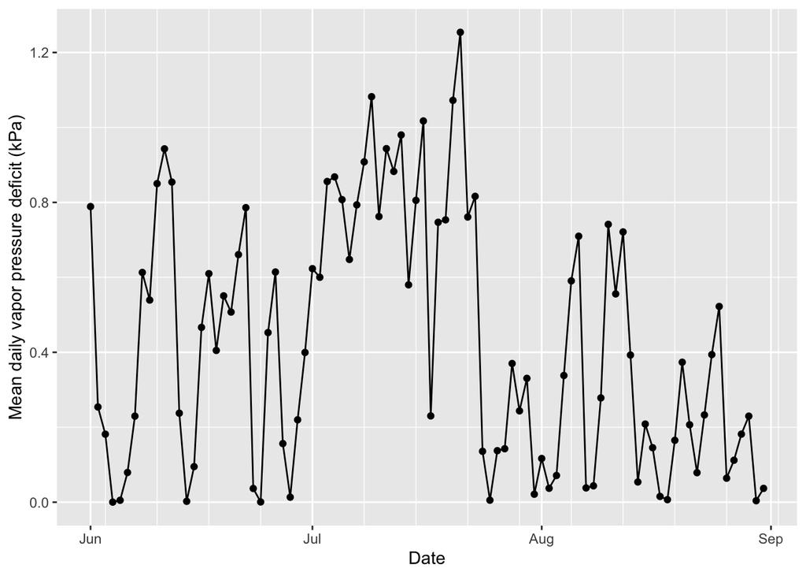

```r
ggplot(data = daily, aes(x=Date, y = MeanVPD)) +
  geom_line() + geom_point() +
  scale_x_date(minor_breaks = "week") +
  scale_y_continuous("Mean daily vapor pressure deficit (kPa)")
```

2. Plot the maximum VPD measured by each logger.

```r
logger <- tapply(X = climate$VPD,
                 INDEX = climate$LoggerID,
                 FUN = max)
logger <- data.frame(logger)
logger$ID <- rownames(logger)

colnames(logger)[1] <- "MaxVPD"
```

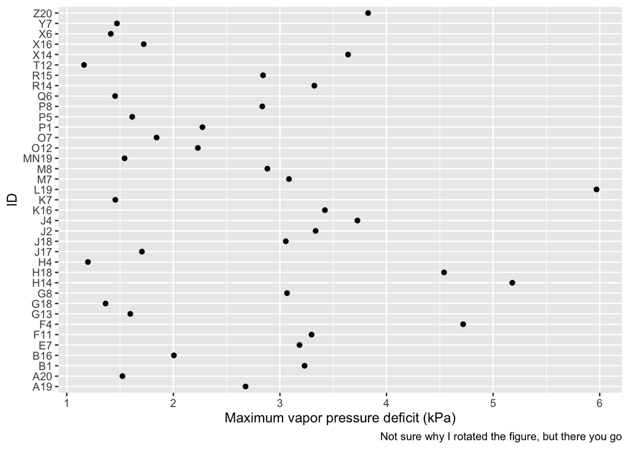

```r
ggplot(data = logger, aes(x=MaxVPD, y = ID)) +
  geom_point() +
  scale_x_continuous("Maximum vapor pressure deficit (kPa)") +
  labs(caption = "Not sure why I rotated the figure, but there you go")
```

## Footnotes

[^1]: We should fix mistakes in our data sets, but any modifications, calculations, or conversions should be done in code.
[^2]: There are probably some specific time-of-day formats, but they are special use cases.
[^3]: “The strain under which an organism is placed in maintaining a water balance during temperature changes is much more clearly shown by noting the vapor pressure deficit than by recording the relative humidity.”Anderson, D. B. 1936. Relative humidity or vapor pressure deficit. Ecology 17, no. 2: 277–282
[^4]: Functions often have sensible default values to use when the argument isn’t specified. You provide these in the function definition, e.g., as `argument1 = 10, argument2 = TRUE`.